# Analysis and figures for poster presented at ESCOP 2019

[Guillermo Montero-Melis](https://www.mpi.nl/people/montero-melis-guillermo)

13/09/2019

# 1 Introduction

Run analysis and create figures for poster presented at ESCoP 2019 conference (Isaksson, Ostarek, and Montero-Melis, 2019).

*NB*: The data has been pre-processed in a separate script (`data/process_data.Rmd`).

# 2 Set up workspace

## 2.1 Libraries

```r
knitr::opts_chunk$set(echo = TRUE)
library(knitr)
library(dplyr)
library(ggplot2)
library(GGally)
library(tidyr)
library(lme4)
```

## 2.2 Data

Matching task:

```r
# Matching task
d_match <- read.csv("../data/data_matching-task.csv", fileEncoding = "UTF-8")
head(d_match)
```

```
##   Subject                 ImageFile Score KeyPress CorrKey   TargetWord
## 1       1  pict_lang_test/bild4.png     1        j       j         comb
## 2       1 pict_lang_test/bild10.png     1        q       q         lamp
## 3       1  pict_lang_test/bild6.png     1        d       d bowling ball
## 4       1 pict_lang_test/bild14.png     1        4       4       violin
## 5       1 pict_lang_test/bild30.png     1        a       a        apple
## 6       1 pict_lang_test/bild23.png     1        s       s    paint can
```

Form/category task:

```r
# form/category task cleaned version (see "~/data/process_data.Rmd" for details)
d_fc <- read.csv("../data/data_form-category-task_cleaned.csv", fileEncoding = "UTF-8")
head(d_fc)
```

```
##   Subject  Task Language Trial Score ItemID Comment
## 1       1 Shape       L1     1     1     22
## 2       1 Shape       L1     2     1     17
## 3       1 Shape       L1     3     1      6
## 4       1 Shape       L1     4     1     16
## 5       1 Shape       L1     5     1      7
## 6       1 Shape       L1     6     1     15
##                                 Descr LangOrder
## 1         1. timglas 2. piano 3. fiol     L2-L1
## 2     1. målarpensel 2. flöjt 3. fiol     L2-L1
## 3      1. klarinett 2. päron 3. banan     L2-L1
## 4 1. färgburk 2. målarpensel 3. banan     L2-L1
## 5      1. flöjt 2. färgburk 3. trumma     L2-L1
## 6  1. lampa 2. ficklampa 3. klarinett     L2-L1
```

Participant background data, including L2 English proficiency (LexTale):

```r
backgr <- read.csv("../data/participant-background.csv", fileEncoding = "UTF-8")
head(backgr)
```

```
##   Subject Age Sex L2_start L2_self Months_L2_country LexTale
## 1       1  38 man        9       5                 0  0.9375
## 2       2  45 man       10       1                 1  0.6125
## 3       3  37 man        7       5                 1  0.8875
## 4       4  33 man        6       7                 1  1.0000
## 5       5  33 man        7       4                 3  0.7000
## 6       6  29 man        9       5                 2  0.8000
```

Inference task:

```r
d_infe <- read.csv("../data/data_inference-task.csv", fileEncoding = "UTF-8",
                   stringsAsFactors = FALSE)
# Want to change "visuospatial" to "spatial" for clarity
d_infe$Type[d_infe$Type == "Visuospatial"] <- "Spatial"
head(d_infe)
```

```
##   Subject Language          Item Trial Score        RT
## 1       1       L1  audio/n7.wav     1     0 2.6119200
## 2       1       L1 audio/n20.wav     2     1 1.0598361
## 3       1       L1 audio/n22.wav     3     1 0.5754024
## 4       1       L1 audio/n17.wav     4     1 0.2093123
## 5       1       L1 audio/n24.wav     5     1 0.3090446
## 6       1       L1 audio/n10.wav     6     1 0.2569126
##                   InferPattern    Type Valid
## 1 1) A-r-B; 2) C-R-B; 3) A-r-C Control     1
## 2 1) B-r-A; 2) C-R-A; 3) B-r-C Control     1
## 3 1) B-r-A; 2) C-R-A; 3) B-r-C Spatial     1
## 4 1) B-r-C; 2) B-R-A; 3) C-r-A Control     0
## 5 1) B-r-C; 2) B-R-A; 3) C-r-A Spatial     0
## 6 1) A-r-B; 2) C-R-B; 3) A-r-C  Visual     1
##                                                  Description
## 1  1) ape-dumber-dog; 2) cat-smarter-dog; 3) ape-dumber-cat?
## 2     1) dog-worse-ape; 2) cat-better-ape; 3) dog-worse-cat?
## 3      1) dog-below-ape; 2) cat-above-ape; 3) dog-below-cat?
## 4     1) dog-worse-cat; 2) dog-better-ape; 3) cat-worse-ape?
## 5      1) dog-below-cat; 2) dog-above-ape; 3) cat-below-ape?
## 6 1) ape-thinner-dog; 2) cat-fatter-dog; 3) ape-thinner-cat?
```

# 3 Matching task

The matching task was used to exclude items in the form/category task for those participants who could not match it correctly (assuming that their performance on such an item is uninformative if they don’t know the meaning of the word).

*NB*: These exclusions resulted in the “cleaned” dataset for the form/category task (see Data above).

How accurate were subjects on this task?

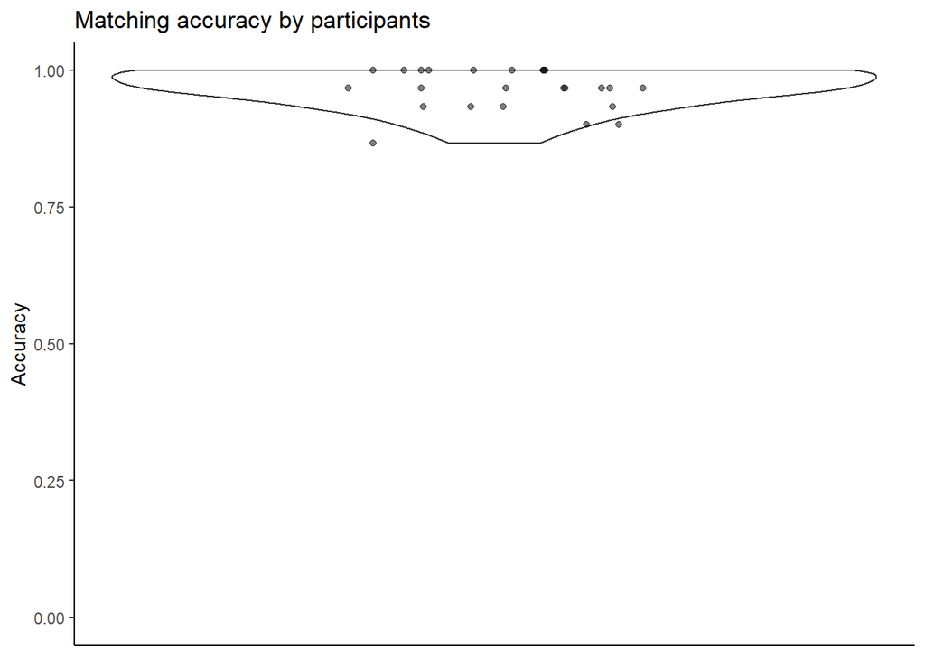

```r
theme_match <- theme_classic() +
  theme(axis.title.x=element_blank(),
        axis.text.x=element_blank(),
        axis.ticks.x=element_blank())

plot <- d_match %>% group_by(Subject) %>% summarise(Accuracy = mean(Score)) %>%
  ggplot(aes(x = 0, y = Accuracy)) +
  ylim(0, 1) +
  geom_violin(width = .5) +
  geom_jitter(height = 0, width = .1, alpha = .5) +
  ggtitle("Matching accuracy by participants")
plot + theme_match
```

Show accuracy by items instead:

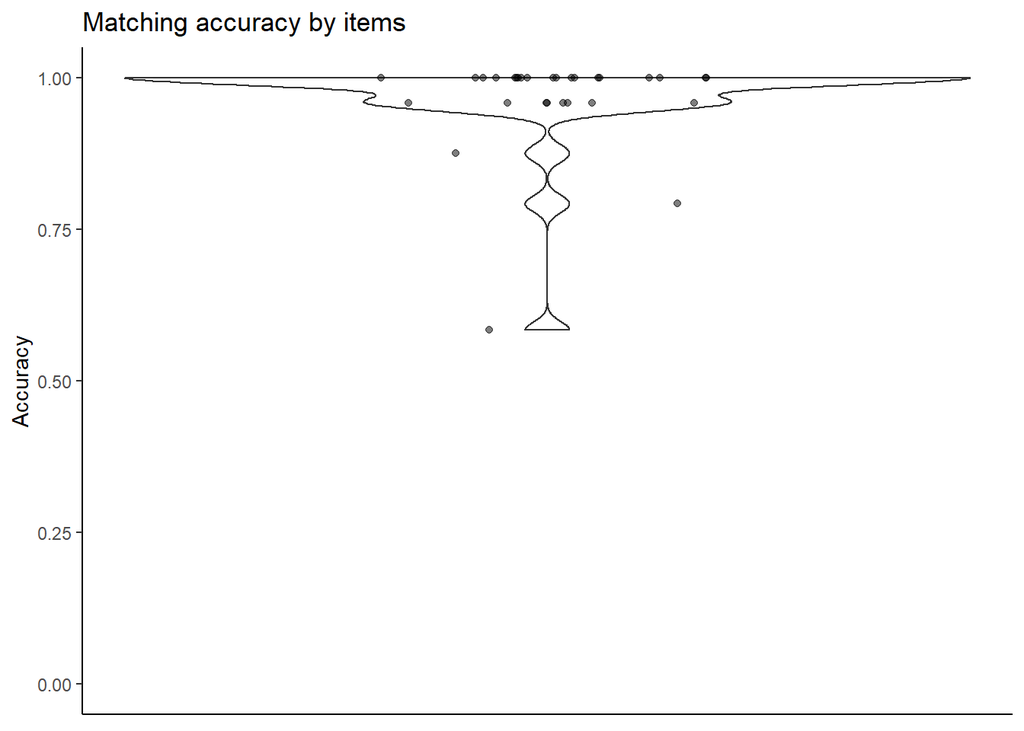

```r
plot <- d_match %>% group_by(TargetWord) %>% summarise(Accuracy = mean(Score)) %>%
  ggplot(aes(x = 0, y = Accuracy)) +
  ylim(0, 1) +
  geom_violin(width = .5) +
  geom_jitter(height = 0, width = .1, alpha = .5) +
  ggtitle("Matching accuracy by items")
plot + theme_match
```

A few items were apparently more difficult, especially “hairspray”:

```r
d_match$Error <- ifelse(d_match$Score == 1, 0, 1)
d_match %>% group_by(TargetWord) %>%
  summarise(NbErrors = sum(Error)) %>%
  arrange(- NbErrors) %>%
  print(n = 5)
```

```
## # A tibble: 30 x 2
##   TargetWord NbErrors
##   <fct>         <dbl>
## 1 hairspray        10
## 2 flute             5
## 3 clarinet          3
## 4 button            1
## 5 coconut           1
## # ... with 25 more rows
```

# 4 Visual imagery task: Shape vs category judgements

## 4.1 By-subject visualization

Summarize each participant’s data as a single number, namely their mean accuracy (`Acc`) in each task and language:

```r
d_fc_subj <- d_fc %>%
  group_by(Subject, Task, Language) %>%
  summarise(Acc = mean(Score))
```

Identify outliers (wrt to Tukey/ggplot2 boxplots):

```r
d_fc_subj <- d_fc %>%
  group_by(Subject, Task, Language) %>%
  summarise(Acc = mean(Score))

# To be able to plot the label names of outliers (SPSS does it by default), we
# adapt the solution proposed in
# https://stackoverflow.com/questions/33524669/labeling-outliers-of-boxplots-in-r
is_outlier <- function(x) {
  return(x < quantile(x, 0.25) - 1.5 * IQR(x) | x > quantile(x, 0.75) + 1.5 * IQR(x))
}
# Outlier contains a subject ID if they are an outlier for a task-language combo
d_fc_subj <- d_fc_subj %>%
  group_by(Task, Language) %>%
  mutate(Outlier = ifelse(is_outlier(Acc), Subject, as.numeric(NA)))
head(d_fc_subj)
```

```
## # A tibble: 6 x 5
## # Groups:   Task, Language [4]
##   Subject Task     Language   Acc Outlier
##     <int> <fct>    <fct>    <dbl>   <dbl>
## 1       1 Category L1           1      NA
## 2       1 Category L2           1      NA
## 3       1 Shape    L1           1      NA
## 4       1 Shape    L2           1      NA
## 5       2 Category L1           1      NA
## 6       2 Category L2           1      NA
```

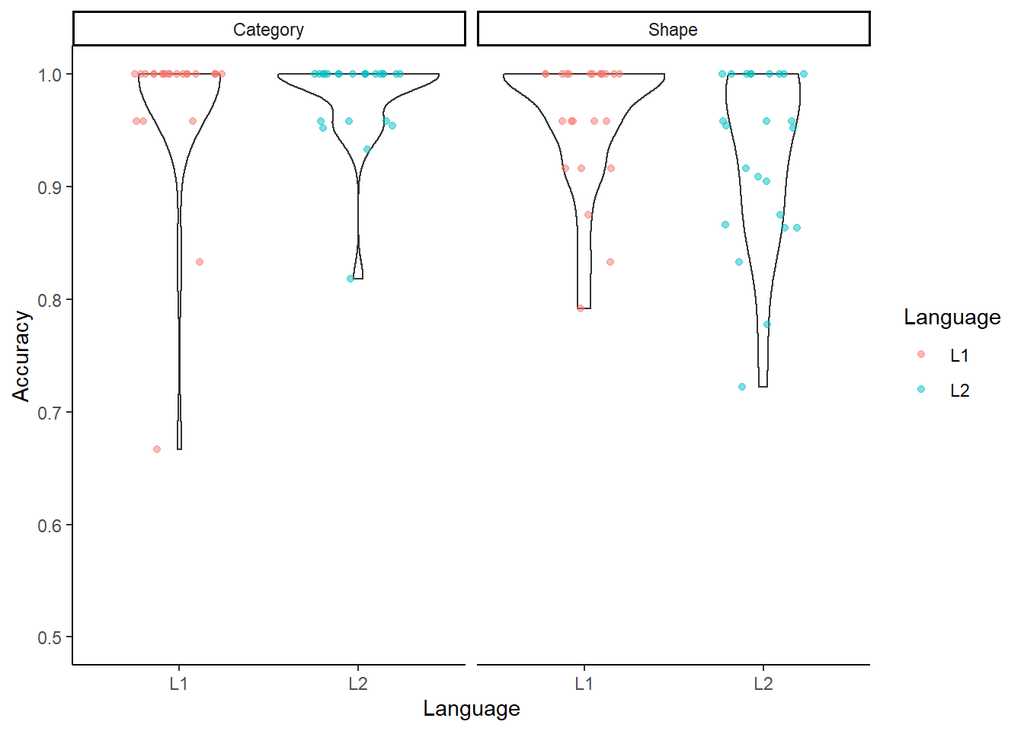

```r
plot <- ggplot(d_fc_subj, aes(x = Language, y = Acc)) +
  geom_violin() +
  geom_jitter(height = 0, width = .25, alpha = .5, aes(colour = Language)) +
  facet_grid(. ~ Task) +
  ylab("Accuracy") +
  ylim(.5, 1)
plot + theme_classic()
```

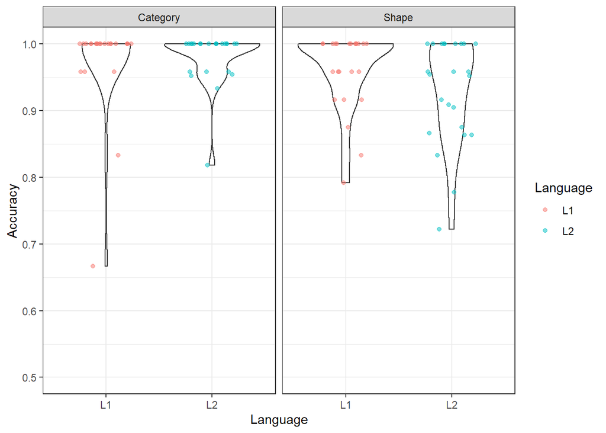

```r
plot +  theme_bw()
```

## 4.2 Generalized Linear Mixed Model (GLMM) analysis

The hypothesis is that there should be an interaction between language and task, such that participants perform worse in the shape task when carrying it out in the L2, but their performance should not be worse in the category task.

```r
# Sum coding for factors
# Task
contrasts(d_fc$Task) <- contr.sum(2)
colnames(contrasts(d_fc$Task)) <- "Categ_vs_Shape"
contrasts(d_fc$Task)
```

```
##          Categ_vs_Shape
## Category              1
## Shape                -1
```

```r
# Language
contrasts(d_fc$Language) <- - contr.sum(2)
colnames(contrasts(d_fc$Language)) <- "L2_vs_L1"
contrasts(d_fc$Language)
```

```
##    L2_vs_L1
## L1       -1
## L2        1
```

```r
# fail to converge...

# fm_fc <- glmer(Score ~ Task * Language +
#                  (Task * Language | Subject) +
#                  (Task * Language | ItemID),
#                data = d_fc,
#                family = "binomial")

# fm_fc <- glmer(Score ~ Task * Language +
#                  (Task * Language | Subject) +
#                  (Task + Language | ItemID),
#                data = d_fc,
#                family = "binomial")

# The only model I can get to converge with any random slope by subjects:
# fm_fc7 <- glmer(Score ~ Task * Language +
#                   (1 + Task | Subject) +
#                   (1 | ItemID),
#                 data = d_fc,
#                 family = "binomial")
# summary(fm_fc7)
```

# 5 Inference task

## 5.1 Accuracy

### 5.1.1 By subject

Summarize each participant’s data as a single number, namely their mean accuracy (`Acc`) in each task and language:

```r
d_infe_subj <- d_infe %>%
  group_by(Subject, Language, Type) %>%
  summarise(Acc = mean(Score))
head(d_infe_subj)
```

```
## # A tibble: 6 x 4
## # Groups:   Subject, Language [2]
##   Subject Language Type      Acc
##     <int> <chr>    <chr>   <dbl>
## 1       1 L1       Control 0.625
## 2       1 L1       Spatial 0.875
## 3       1 L1       Visual  1
## 4       1 L2       Control 1
## 5       1 L2       Spatial 0.625
## 6       1 L2       Visual  1
```

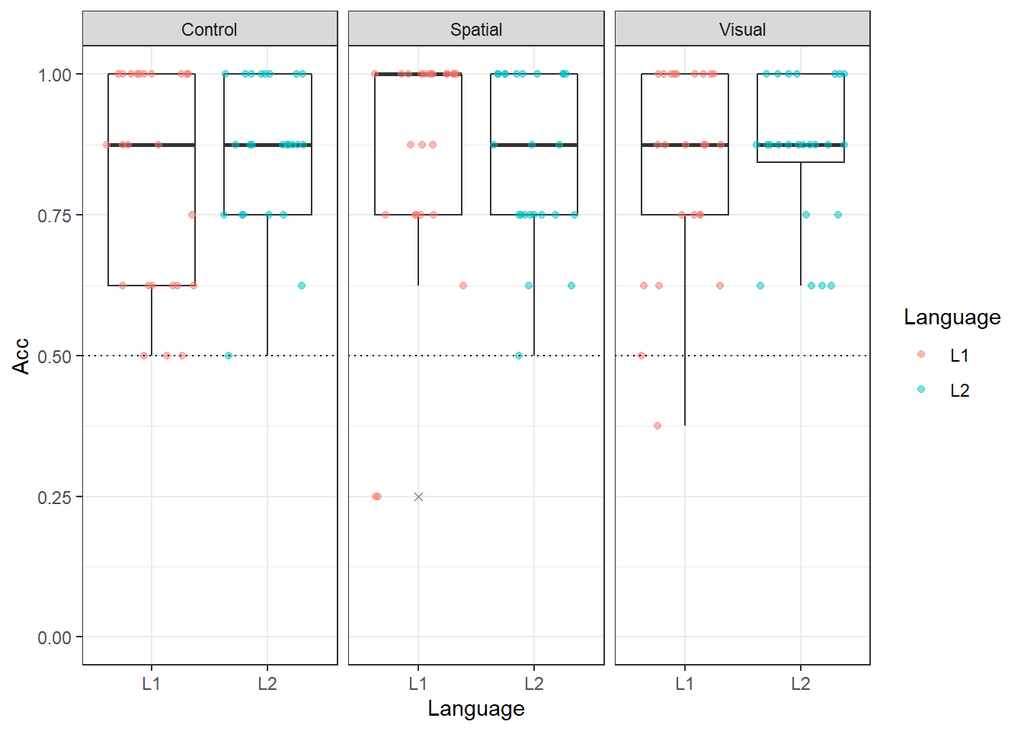

```r
ggplot(d_infe_subj, aes(x = Language, y = Acc)) +
  geom_boxplot(outlier.shape = 4) +
  geom_jitter(height = 0, alpha = .5, aes(colour = Language)) +
  facet_grid(. ~ Type) +
  ylim(0, 1) +
  geom_hline(yintercept = .5, linetype = "dotted") +
  theme_bw()
```

Let us see if either the valid or invalid inferences were more difficult:

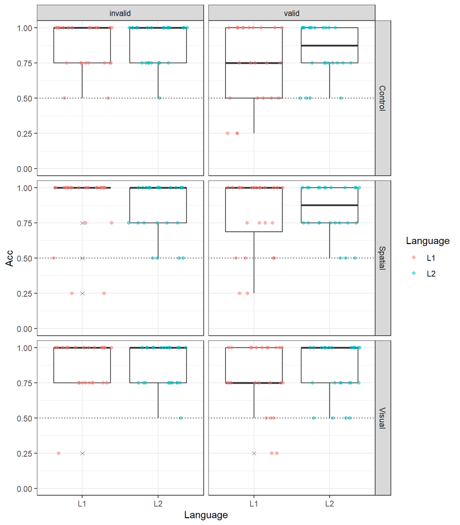

```r
d_infe %>%
  mutate(Val = ifelse(Valid == 1, "valid", "invalid")) %>%
  group_by(Subject, Language, Type, Val) %>%
  summarise(Acc = mean(Score)) %>%
  ggplot(aes(x = Language, y = Acc)) +
  geom_boxplot(outlier.shape = 4) +
  geom_jitter(height = 0, alpha = .5, aes(colour = Language)) +
  facet_grid(Type ~ Val) +
  ylim(0, 1) +
  geom_hline(yintercept = .5, linetype = "dotted") +
  theme_bw()
```

There is actually not much evidence that invalid inferences are harder than valid ones, or the other way around.

### 5.1.2 By-item (i.e., by inference pattern)

Let’s do an analogous visualization but now grouping by inference pattern (`InferPattern`) rather than subject:

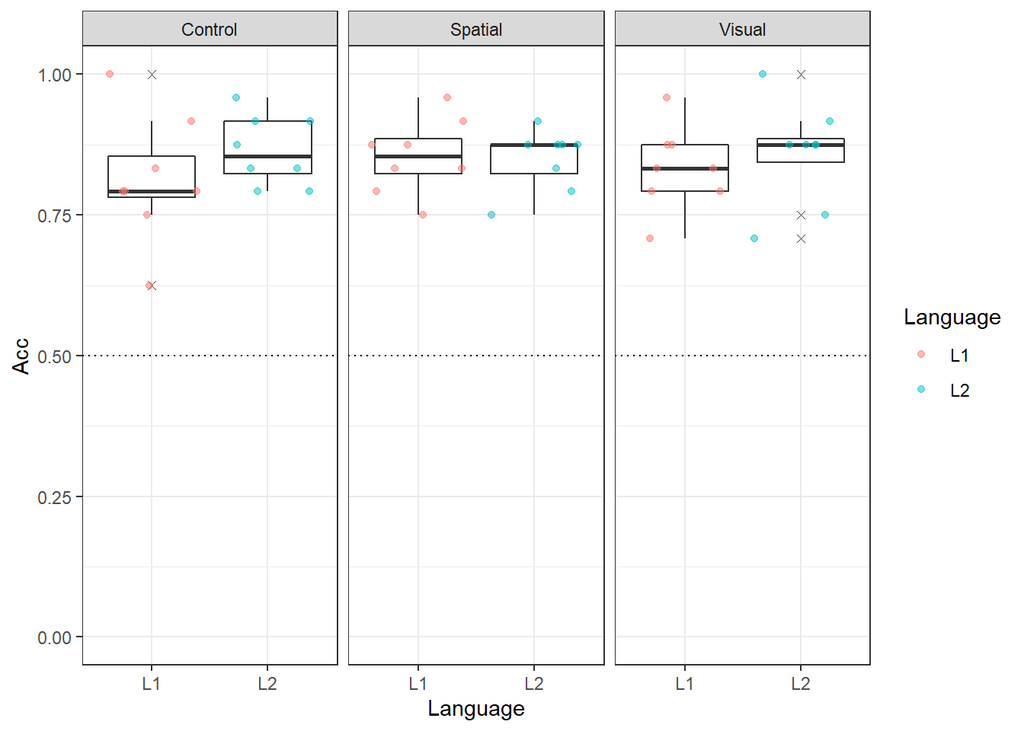

```r
d_infe_ite <- d_infe %>%
  mutate(Val = ifelse(Valid == 1, "valid", "invalid")) %>%
  group_by(InferPattern, Language, Type, Val) %>%
  summarise(Acc = mean(Score))

ggplot(d_infe_ite, aes(x = Language, y = Acc)) +
  geom_boxplot(outlier.shape = 4) +
  geom_jitter(height = 0, alpha = .5, aes(colour = Language)) +
  facet_grid(. ~ Type) +
  ylim(0, 1) +
  geom_hline(yintercept = .5, linetype = "dotted") +
  theme_bw()
```

Interestingly, there seems to be less variation in the items than in subjects. So all inference patterns were roughly equally hard.

We can also colour the dots with regard to validity of the items, to see if we see some evidence now of valid vs invalid items having a different degree of difficulty:

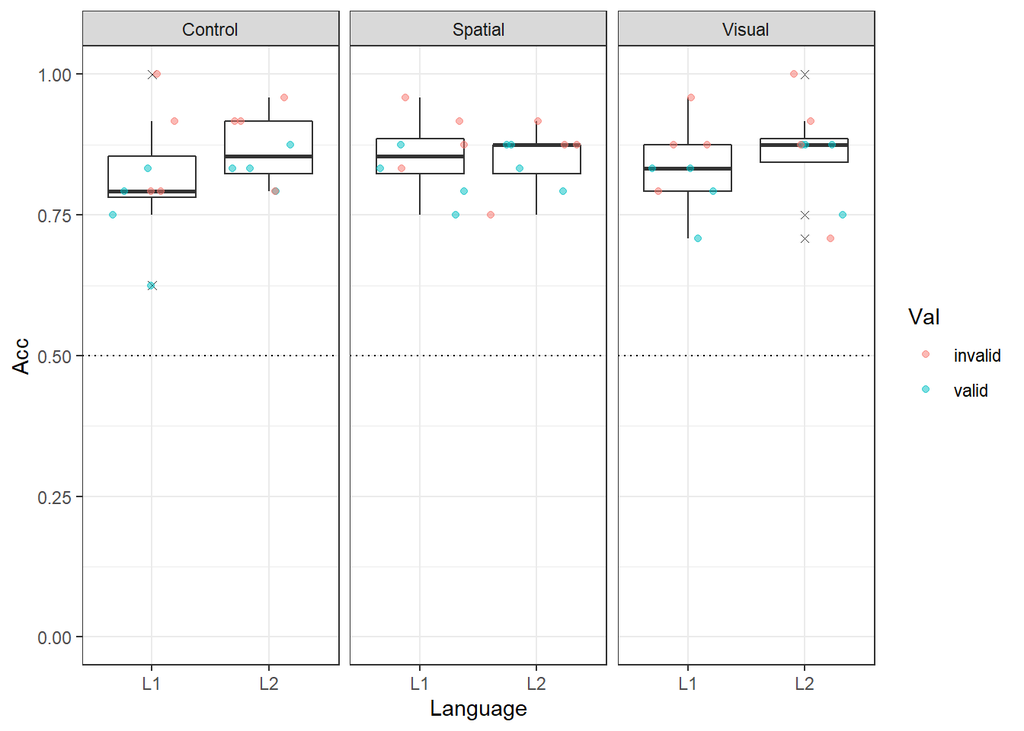

```r
ggplot(d_infe_ite, aes(x = Language, y = Acc)) +
  geom_boxplot(outlier.shape = 4) +
  geom_jitter(height = 0, alpha = .5, aes(colour = Val)) +
  facet_grid(. ~ Type) +
  ylim(0, 1) +
  geom_hline(yintercept = .5, linetype = "dotted") +
  theme_bw()
```

We can make the comparison even more explicit, as we did above between subjects:

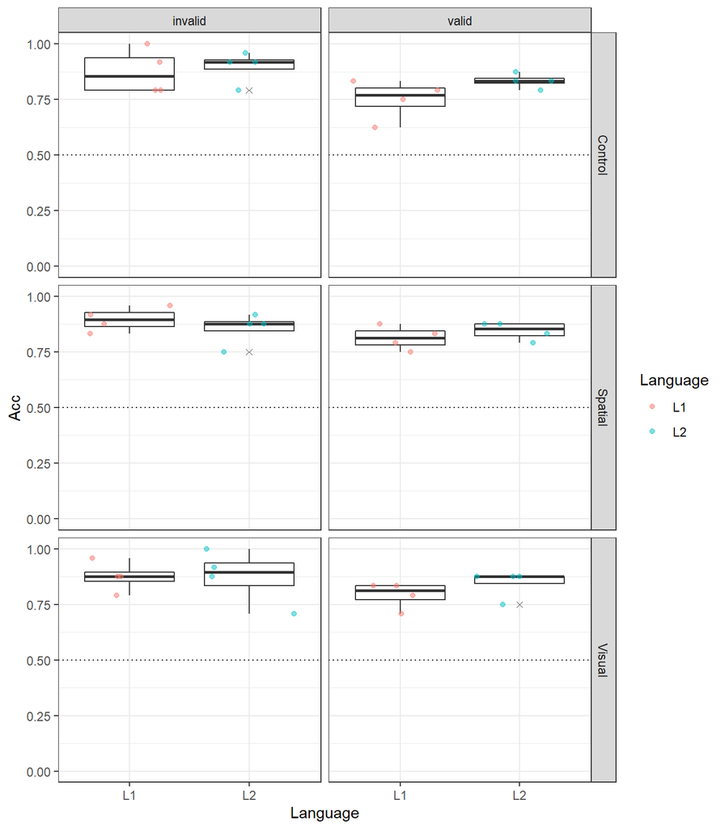

```r
ggplot(d_infe_ite, aes(x = Language, y = Acc)) +
  geom_boxplot(outlier.shape = 4) +
  geom_jitter(height = 0, alpha = .5, aes(colour = Language)) +
  facet_grid(Type ~ Val) +
  ylim(0, 1) +
  geom_hline(yintercept = .5, linetype = "dotted") +
  theme_bw()
```

Perhaps there is an indication that invalid inferences yielded slightly higher accuracies. This in turn could be due to participants having a slight bias towards rejecting the validity of inferences…

**It would probably be a good idea to compute d’ (*d-prime*) scores!**

## 5.2 Response times

### 5.2.1 General overview

First we need to get an idea of how response times (RTs) were distributed: How much dispersion was there within and between participants? Were the distributions very skewed?

```r
# Compute by speaker averages for later plotting and add that to data frame
mean_RT <- d_infe %>% group_by(Subject) %>%
  summarise(Mean_RT = mean(RT),
            Median_RT = median(RT))
d_infe <- left_join(d_infe, mean_RT)
# Order Subject levels according to Median_RT
d_infe$Subject <- factor(d_infe$Subject, levels = mean_RT$Subject[order(mean_RT$Median_RT)])
```

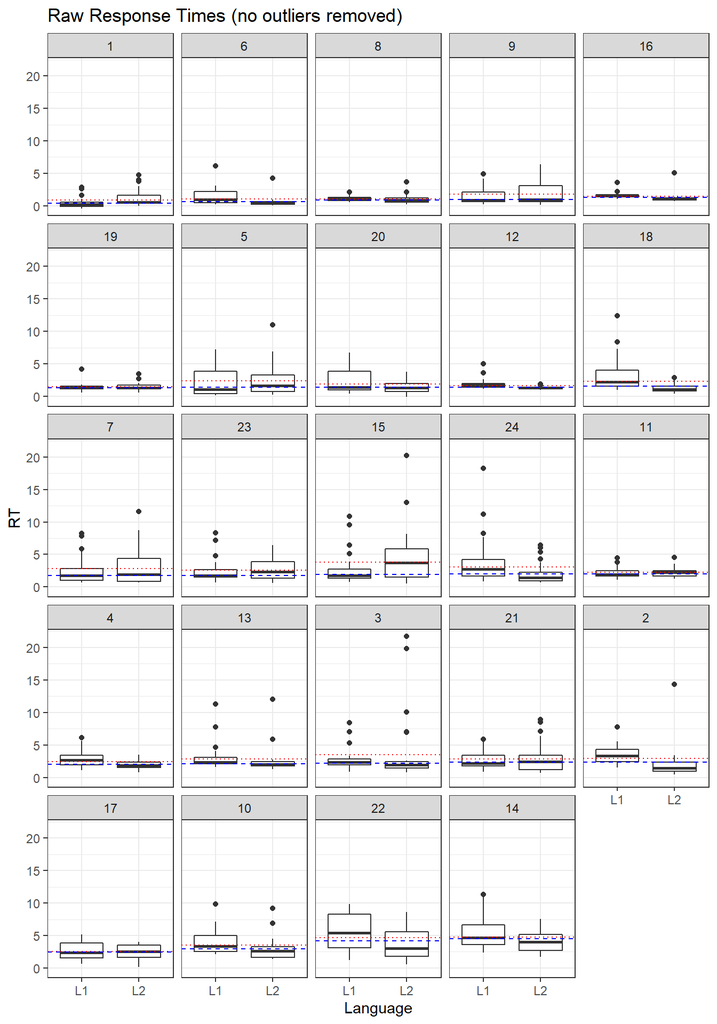

```r
ggplot(d_infe, aes(x = Language, y = RT)) +
  geom_boxplot() +
  facet_wrap(~ Subject) +
  geom_hline(aes(yintercept = Mean_RT), linetype = "dotted", colour = "red") +
  geom_hline(aes(yintercept = Median_RT), linetype = "dashed", colour = "blue") +
  ggtitle("Raw Response Times (no outliers removed)") +
  theme_bw()
```

The plots show that the data are very skewed, as is typical in RTs.

Here is a data summary:

```r
summary(d_infe$RT)
```

```
##    Min. 1st Qu.  Median    Mean 3rd Qu.    Max.
## -0.4097  1.1421  1.8107  2.5256  3.1631 21.6835
```

While 75% of the data are RT < 3.163059, extreme observations go above 20 seconds!

### 5.2.2 Correct vs incorrect trials

In the previous section, we looked at all the trials, independent of whether participants’ responses were correct or not. However, Knauff and May (2006) removed incorrect trials from the RT analyses, and so did Petrus. This is standard practice and it actually makes sense because one may wonder if subjects were even paying attention on incorrect trials.

First, let’s see RTs as a function of response accuracy:

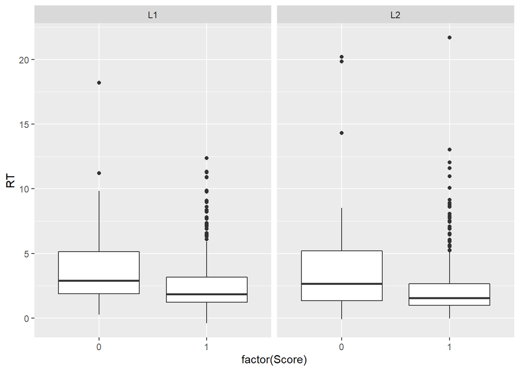

```r
ggplot(d_infe, aes(x = factor(Score), y = RT)) +
  geom_boxplot() +
  facet_grid(. ~ Language)
```

Indeed, in both L1 and L2 there is a tendency for incorrect trials to be associated to longer RTs:

```r
d_infe %>% group_by(Language, Score) %>%
  summarise(Mean_RT = mean(RT), SD_RT = sd(RT)) %>%
  kable
```

| Language | Score | Mean_RT | SD_RT |
| --- | --- | --- | --- |
| L1 | 0 | 3.811636 | 2.773496 |
| L1 | 1 | 2.460196 | 2.037651 |
| L2 | 0 | 3.665301 | 3.607126 |
| L2 | 1 | 2.150091 | 2.048157 |

Yes, the mean effect is indeed quite substantial: incorrect responses yield roughly 1.5 seconds longer RTs.

See the script `analysis/first-pass_analysis.Rmd` for a more detailed breakdown of incorrect responses by participants and by items.

### 5.2.3 Exclude incorrect trials

In any case, it makes sense to exclude incorrect trials from further analysis:

```r
d_infe_corr <- d_infe %>% filter(Score == 1)
```

### 5.2.4 Log-transorm the data to avoid the strong right-skew?

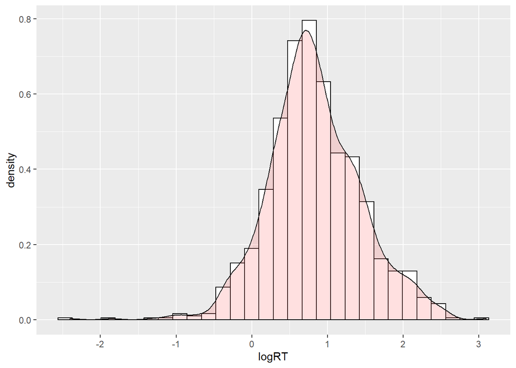

```r
# Because log of negative number is not defined, we somewhat arbitrarily add
# 0.5 to all RTs (just a shift in scale) to make them all positive:
d_infe_corr$logRT <- log(d_infe_corr$RT + 0.5)
ggplot(d_infe_corr, aes(x = logRT)) +
  geom_histogram(aes(y=..density..),  # Histogram with density instead of count on y-axis
                 colour="black", fill="white") +
  geom_density(alpha=.2, fill="#FF6666")  # Overlay with transparent density plot
```

The distribution of `logRT`s is much less skewed, although we might now observe a slight left-skew instead. Note that this transformation is a monotonically increasing function, so the order of the observations is preserved.

Let us look at the same plot of by-subject observations as above, but now using the log-transformed RT data.

```r
# Compute by speaker averages and medians for logRT
mean_logRT <- d_infe_corr %>% group_by(Subject) %>%
  summarise(Mean_logRT = mean(logRT),
            Median_logRT = median(logRT))
d_infe_corr <- left_join(d_infe_corr, mean_logRT)
# Order Subject levels according to Median_logRT now
d_infe_corr$Subject <- factor(
  d_infe_corr$Subject,
  levels = mean_logRT$Subject[order(mean_logRT$Median_logRT)]
  )
```

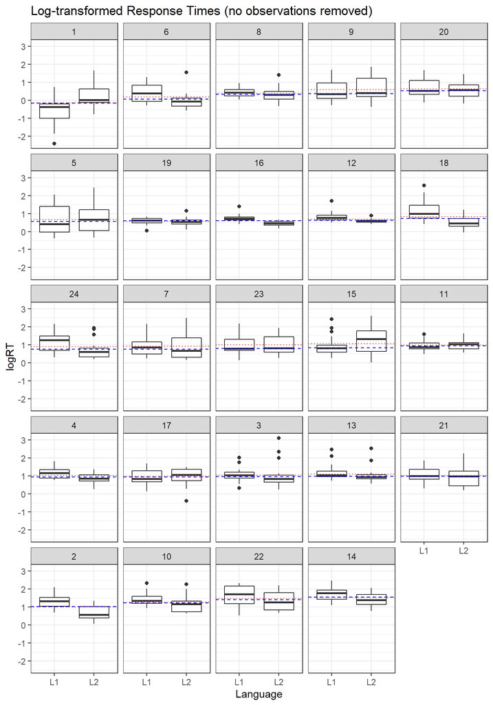

```r
ggplot(d_infe_corr, aes(x = Language, y = logRT)) +
  geom_boxplot() +
  facet_wrap(~ Subject) +
  geom_hline(aes(yintercept = Mean_logRT), linetype = "dotted", colour = "red") +
  geom_hline(aes(yintercept = Median_logRT), linetype = "dashed", colour = "blue") +
  ggtitle("Log-transformed Response Times (no observations removed)") +
theme_bw()
```

Under the log transformation, the problem of removing outliers, which always involves arbitrary cutoffs, is largely avoided.

We proceed with log-transformed data for all RT analyses.

A note on the interpretation of log-RTs in regression analysis:

There is a different assumption underlying the choice of whether to analyze the dependent variable reaction time as raw scores or on a logarithmic scale. The assumption has to do with how one believes the manipulations to be related to the DV. Taking raw RTs assumes that the effect of the predictor on the DV will be linear, i.e. a regression coefficient of 2 would indicate that RTs increase by adding 2 for any unit you move on the predictor. However, if you model the DV as logRT, we assume that the effect is multiplicative. This means that a regression coefficient of 2 indicates that RTs are *multiplied* by 2.

This is important to keep in mind for the interpretation of the analyses.

### 5.2.5 By subject

```r
# Summarize RTs by subject
rt_subj <- d_infe_corr %>%
  group_by(Subject, Language, Type) %>%
  summarise(logRT = mean(logRT))
head(rt_subj, 7)
```

```
## # A tibble: 7 x 4
## # Groups:   Subject, Language [3]
##   Subject Language Type      logRT
##   <fct>   <chr>    <chr>     <dbl>
## 1 1       L1       Control -0.467
## 2 1       L1       Spatial -0.475
## 3 1       L1       Visual  -0.749
## 4 1       L2       Control  0.0778
## 5 1       L2       Spatial  0.245
## 6 1       L2       Visual   0.470
## 7 6       L1       Control  0.200
```

Overlay the individual subject means to the cell means and 95% CIs (assuming normality, i.e. +/- 2 SE) to get a better idea of the dispersion in the data. (assuming normality, i.e. +/- 2 SE).

```r
sem_fun <- function(x) sd(x) / sqrt(length(x))
rt_subj_summ <- rt_subj %>%
  group_by(Language, Type) %>%
  summarise(M = mean(logRT), SE = sem_fun(logRT))
rt_subj_summ
```

```
## # A tibble: 6 x 4
## # Groups:   Language [2]
##   Language Type        M     SE
##   <chr>    <chr>   <dbl>  <dbl>
## 1 L1       Control 0.873 0.102
## 2 L1       Spatial 0.888 0.0959
## 3 L1       Visual  1.01  0.116
## 4 L2       Control 0.739 0.0872
## 5 L2       Spatial 0.841 0.0760
## 6 L2       Visual  0.788 0.0748
```

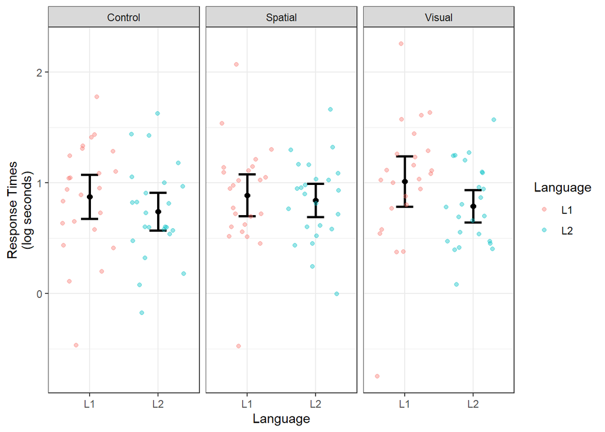

```r
plot_infer_RT <- ggplot(rt_subj_summ, aes(x = Language, y = M)) +
  geom_point(size = 2) +
  geom_errorbar(aes(ymin = M - 1.96 * SE, ymax = M + 1.96 * SE), width = .25,
                size = 1) +
  geom_jitter(data = rt_subj, aes(y = logRT, colour = Language), height = 0,
              alpha = .4) +
  facet_grid(. ~ Type) +
  ylab("Response Times\n(log seconds)") +
  theme_bw()
plot_infer_RT
```

At least numerically, the data suggest the expected tendency: The visual type of inferences were more demanding in the L1 than in the L2.

We can add a little bit more of information to the graph by connecting observations from the same speaker in the different languages. This basically shows individual by-subject slopes (as will later be captured by the random effects in linear mixed model, LMM).

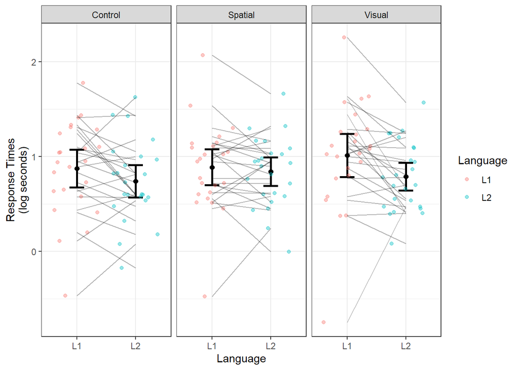

```r
plot_infer_RT +
  geom_line(data = rt_subj, aes(y = logRT, group = Subject), alpha = .3)
```

Save to disk (perhaps uncomment next line?)

```r
# ggsave("fig_exp2_amlap.png", height = 2.5, width = 5)
# ggsave("fig_exp2_amlap.pdf", height = 2.5, width = 5)
```

### 5.2.6 LMM analysis

Appropriate coding for factors:

```r
# Sum coding for Language
d_infe_corr$Language <- factor(d_infe_corr$Language)
contrasts(d_infe_corr$Language) <- - contr.sum(2)
colnames(contrasts(d_infe_corr$Language)) <- "L2_vs_L1"
contrasts(d_infe_corr$Language)
```

```
##    L2_vs_L1
## L1       -1
## L2        1
```

```r
# Inference Type: Helmert coding
d_infe_corr$Type <- factor(d_infe_corr$Type)
contrasts(d_infe_corr$Type) <- contr.helmert(3)
colnames(contrasts(d_infe_corr$Type)) <- c("Spat_vs_Cont", "Visual_vs_rest")
contrasts(d_infe_corr$Type)
```

```
##         Spat_vs_Cont Visual_vs_rest
## Control           -1             -1
## Spatial            1             -1
## Visual             0              2
```

```r
contrasts(d_infe_corr$Language)
```

```
##    L2_vs_L1
## L1       -1
## L2        1
```

Run the models (or comment them as they take a long time)

```r
# # Start with full model as per Barr et al. (2013)
# fm_RT <- lmer(
#   logRT ~ Language * Type +
#     (1 + Language * Type | Subject) +
#     (1 + Language * Type | InferPattern),
#   data = d_infe_corr, REML = FALSE
#   )
# # boundary (singular) fit: see ?isSingular
#
# # Stepwise simplification:
# fm_RT <- lmer(
#   logRT ~ Language * Type +
#     (1 + Language * Type | Subject) +
#     (1 + Language + Type | InferPattern),
#   data = d_infe_corr, REML = FALSE
#   )
# # boundary (singular) fit: see ?isSingular
#
# fm_RT <- lmer(
#   logRT ~ Language * Type +
#     (1 + Language * Type | Subject) +
#     (1 + Language | InferPattern),
#   data = d_infe_corr, REML = FALSE
#   )
# # boundary (singular) fit: see ?isSingular
#
# fm_RT <- lmer(
#   logRT ~ Language * Type +
#     (1 + Language + Type | Subject) +
#     (1 + Language | InferPattern),
#   data = d_infe_corr, REML = FALSE
#   )
# # Model failed to converge with max|grad| = 0.0143437 (tol = 0.002, component 1)
#
# fm_RT <- lmer(
#   logRT ~ Language * Type +
#     (1 + Language | Subject) +
#     (1 + Language | InferPattern),
#   data = d_infe_corr, REML = FALSE
#   )
# # Model failed to converge with max|grad| = 0.0306014 (tol = 0.002, component 1)

fm_RT <- lmer(
  logRT ~ Language * Type +
    (1 + Language | Subject) +
    (1 | InferPattern),
  data = d_infe_corr, REML = FALSE
  )
# This one converges
summary(fm_RT)
```

```
## Linear mixed model fit by maximum likelihood  ['lmerMod']
## Formula:
## logRT ~ Language * Type + (1 + Language | Subject) + (1 | InferPattern)
##    Data: d_infe_corr
##
##      AIC      BIC   logLik deviance df.resid
##   1477.4   1531.1   -727.7   1455.4      963
##
## Scaled residuals:
##     Min      1Q  Median      3Q     Max
## -4.1697 -0.6182 -0.1142  0.4676  4.3716
##
## Random effects:
##  Groups       Name             Variance  Std.Dev. Corr
##  Subject      (Intercept)      0.1358151 0.36853
##               LanguageL2_vs_L1 0.0171837 0.13109  -0.50
##  InferPattern (Intercept)      0.0001554 0.01247
##  Residual                      0.2341700 0.48391
## Number of obs: 974, groups:  Subject, 24; InferPattern, 8
##
## Fixed effects:
##                                     Estimate Std. Error t value
## (Intercept)                          0.85036    0.07698  11.047
## LanguageL2_vs_L1                    -0.06316    0.03102  -2.036
## TypeSpat_vs_Cont                     0.02475    0.01906   1.299
## TypeVisual_vs_rest                   0.02082    0.01101   1.892
## LanguageL2_vs_L1:TypeSpat_vs_Cont    0.02320    0.01905   1.218
## LanguageL2_vs_L1:TypeVisual_vs_rest -0.01843    0.01101  -1.674
##
## Correlation of Fixed Effects:
##             (Intr) LnL2__L1 TyS__C TypV__ LL2__L1:TS
## LnggL2_v_L1 -0.423
## TypSpt_vs_C -0.001  0.006
## TypVsl_vs_r -0.001  0.001    0.004
## LL2__L1:TS_  0.003 -0.003   -0.017 -0.010
## LL2__L1:TV_  0.000 -0.002   -0.009 -0.020  0.004
```

```r
# Model WITHOUT critical interaction
fm_RT_nointeract <- lmer(
  logRT ~ Language + Type +
    (1 + Language | Subject) +
    (1 | InferPattern),
  data = d_infe_corr, REML = FALSE
  )
summary(fm_RT_nointeract)
```

```
## Linear mixed model fit by maximum likelihood  ['lmerMod']
## Formula:
## logRT ~ Language + Type + (1 + Language | Subject) + (1 | InferPattern)
##    Data: d_infe_corr
##
##      AIC      BIC   logLik deviance df.resid
##   1477.7   1521.6   -729.8   1459.7      965
##
## Scaled residuals:
##     Min      1Q  Median      3Q     Max
## -4.0866 -0.6132 -0.1177  0.4860  4.2840
##
## Random effects:
##  Groups       Name             Variance  Std.Dev. Corr
##  Subject      (Intercept)      0.1361958 0.36905
##               LanguageL2_vs_L1 0.0170190 0.13046  -0.50
##  InferPattern (Intercept)      0.0001943 0.01394
##  Residual                      0.2352568 0.48503
## Number of obs: 974, groups:  Subject, 24; InferPattern, 8
##
## Fixed effects:
##                    Estimate Std. Error t value
## (Intercept)         0.85018    0.07712  11.024
## LanguageL2_vs_L1   -0.06318    0.03093  -2.043
## TypeSpat_vs_Cont    0.02484    0.01910   1.301
## TypeVisual_vs_rest  0.02059    0.01103   1.866
##
## Correlation of Fixed Effects:
##             (Intr) LL2__L TyS__C
## LnggL2_v_L1 -0.425
## TypSpt_vs_C -0.001  0.006
## TypVsl_vs_r -0.001  0.001  0.004
```

Model comparison by LRT

```r
anova(fm_RT, fm_RT_nointeract)
```

```
## Data: d_infe_corr
## Models:
## fm_RT_nointeract: logRT ~ Language + Type + (1 + Language | Subject) + (1 | InferPattern)
## fm_RT: logRT ~ Language * Type + (1 + Language | Subject) + (1 | InferPattern)
##                  Df    AIC    BIC  logLik deviance  Chisq Chi Df
## fm_RT_nointeract  9 1477.7 1521.6 -729.84   1459.7
## fm_RT            11 1477.4 1531.1 -727.69   1455.4 4.2899      2
##                  Pr(>Chisq)
## fm_RT_nointeract
## fm_RT                0.1171
```

The interaction of Type and Language does not come out as significant.

### 5.2.7 A somewhat indirect subject analysis

One could also see if there is a correlation between how proficient speakers are in their L2 and how much of a “penalty” they pay for doing the inferences of the visual type.

The idea would here be that the lower your L2 proficiency is, the bigger the difference should be between how fast you are answering these inferences in your L1 and L2, and crucially, the relation should be as follows:

**Prediction**:

With lower L2 proficiency, the difference between RTs in the L1 and L2 for visual inferences should be greater (with an advantage in L2); with higher proficiency, the difference in RTs should be reduced or even zero.

Let us compute, for each subject, the difference in their L1/L2 RTs for visual items:

```r
# Subset form/category task data in L2 only:
d_fc_l2 <- d_fc_subj %>% select(-Outlier) %>% filter(Language == "L2")
# Add their proficiency scores:
d_fc_l2 <- left_join(d_fc_l2, backgr %>% select(Subject, LexTale))
RTs_proficiency <- d_infe_corr %>%
  filter(Type == "Visual") %>%
  group_by(Subject, Language) %>%
  summarise(M = mean(logRT)) %>%
  # From long to wide
  spread(Language, M) %>%
  # compute difference
  mutate(L1_minus_L2 = L1 - L2) %>%
  # Join with information about proficiency and accuracy in the shape task
  left_join(d_fc_l2 %>%
              ungroup() %>%
              mutate(Subject = as.character(Subject)) %>%
              filter(Task == "Shape") %>%
              select(Subject, Acc, LexTale))
head(RTs_proficiency)
```

```
## # A tibble: 6 x 6
## # Groups:   Subject [6]
##   Subject     L1     L2 L1_minus_L2   Acc LexTale
##   <chr>    <dbl>  <dbl>       <dbl> <dbl>   <dbl>
## 1 1       -0.749 0.470      -1.22   1       0.938
## 2 6        0.373 0.0806      0.293  0.909   0.8
## 3 8        0.379 0.405      -0.0255 0.958   0.825
## 4 9        0.769 0.781      -0.0115 0.955   0.625
## 5 20       0.577 0.697      -0.121  1       0.938
## 6 5        1.61  0.660       0.951  0.864   0.7
```

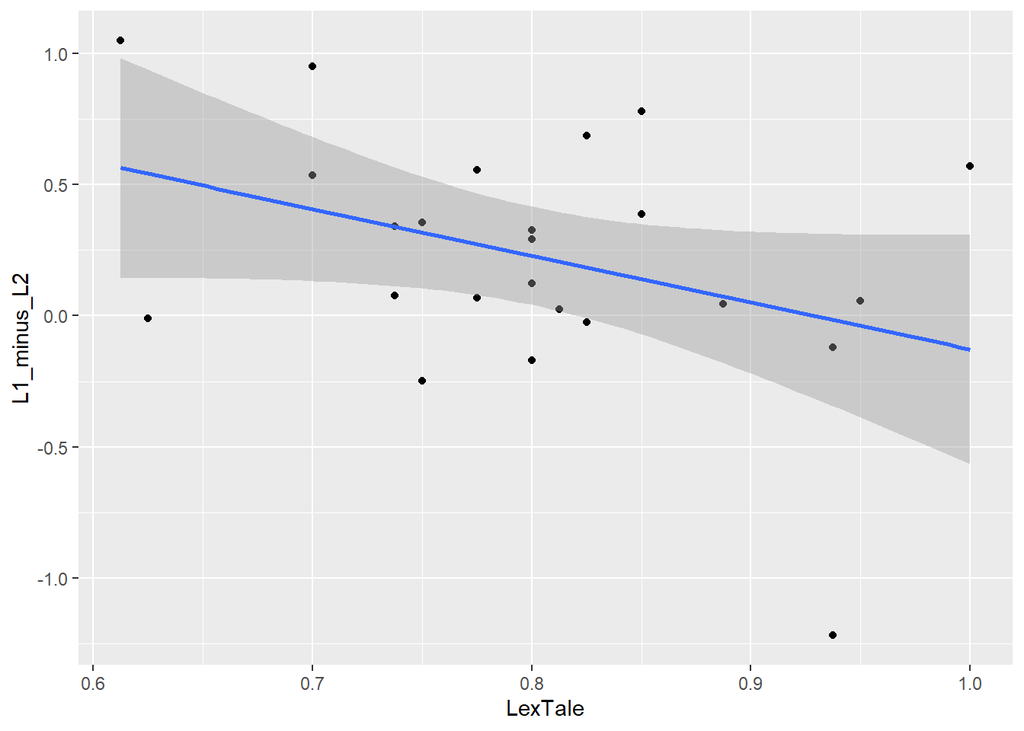

```r
ggplot(RTs_proficiency, aes(x = LexTale, y = L1_minus_L2)) +
  geom_point() +
  geom_smooth(method = "lm")
```

Pearson correlation test

```r
with(RTs_proficiency, cor.test(L1_minus_L2, LexTale))
```

```
##
##  Pearson's product-moment correlation
##
## data:  L1_minus_L2 and LexTale
## t = -1.8669, df = 22, p-value = 0.0753
## alternative hypothesis: true correlation is not equal to 0
## 95 percent confidence interval:
##  -0.67283276  0.03947676
## sample estimates:
##        cor
## -0.3698091
```

What about the accuracy?

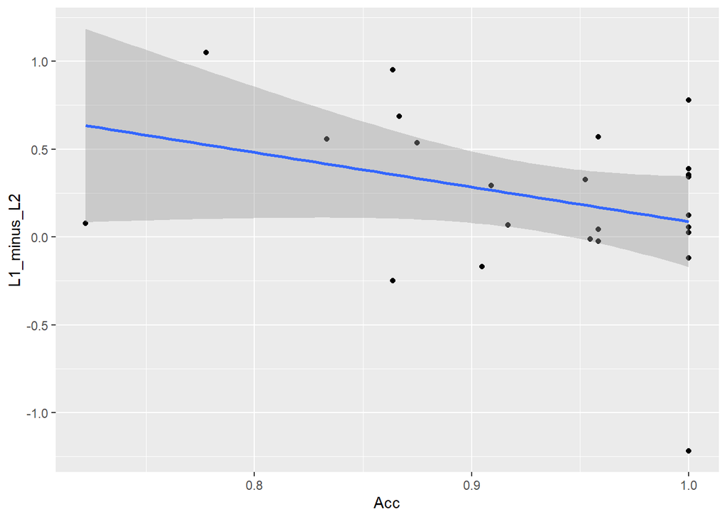

```r
ggplot(RTs_proficiency, aes(x = Acc, y = L1_minus_L2)) +
  geom_point() +
  geom_smooth(method = "lm")
```

Nahh…

```r
with(RTs_proficiency, cor.test(L1_minus_L2, Acc))
```

```
##
##  Pearson's product-moment correlation
##
## data:  L1_minus_L2 and Acc
## t = -1.6426, df = 22, p-value = 0.1147
## alternative hypothesis: true correlation is not equal to 0
## 95 percent confidence interval:
##  -0.64757905  0.08408147
## sample estimates:
##        cor
## -0.3305261
```